# Étude du cours du CAC40

Elliot Rault-Maisonneuve, Benoit Grandlin

2025-01-16

# Introduction

Dans ce projet, nous nous intéressons à l’analyse et à la prévision de l’indice boursier CAC 40, principal indice de référence de la Bourse de Paris. L’objectif est double : étudier le comportement temporel de la série des cours d’ouverture du CAC 40 et réaliser des prévisions sur le mois de janvier 2025 à l’aide de différents modèles statistiques.

L’analyse débute par un pré-traitement des données, incluant le nettoyage, le traitement des valeurs manquantes et l’intégration de données calendaires (jours fériés, vacances de Noël, etc.). Ensuite, nous explorons la structure temporelle de la série, en mettant l’accent sur sa saisonnalité, sa tendance et son caractère potentiellement non stationnaire. Des tests statistiques comme le test de Dickey-Fuller augmenté (ADF) et le test de Phillips-Perron viennent étayer nos observations graphiques.

Pour la partie modélisation, nous comparons trois approches classiques de prévision des séries temporelles :

le modèle ARIMA,

la méthode de Holt-Winters,

et l’algorithme Prophet développé par Facebook.

Chaque méthode est évaluée en termes de cohérence avec les données réelles de janvier 2025, ce qui permet de juger de leur pertinence dans un contexte boursier.

# Etude des données manquantes, valeurs aberrantes, extrêmes, jours ouvrés …

```r
#Ajout des dates jours fériés
CAC40 <- left_join(calendrier_sans_we, CAC40, by = "Date")

#Suppresssion des variables inutilisées
CAC40 <- CAC40[,c(1,3)]

#Combien de données manquantes/aberrantes/extrêmes ? (Jours fériés sur 2 ans)
summary(CAC40)
```

```
##       Date                          Ouverture
##  Min.   :2023-01-02 00:00:00.00   Min.   :6521
##  1st Qu.:2023-07-03 06:00:00.00   1st Qu.:7240
##  Median :2024-01-01 12:00:00.00   Median :7391
##  Mean   :2023-12-31 21:39:18.61   Mean   :7446
##  3rd Qu.:2024-07-01 18:00:00.00   3rd Qu.:7594
##  Max.   :2024-12-31 00:00:00.00   Max.   :8242
##                                   NA's   :11
```

```r
remplace_NA <- function(data) {
  # Vérifie que le data.frame a au moins deux colonnes
  if (ncol(data) < 2) {
    stop("Le data.frame doit avoir au moins deux colonnes (Date et Valeur).")
  }

  # Parcourt chaque ligne
  for (i in 1:nrow(data)) {
    # Si une valeur est manquante
    if (is.na(data[i, 2])) {
      # Vérifie que les indices autour de la ligne actuelle sont valides
      indices <- c((i-3):(i-1), (i+1):(i+3))
      indices <- indices[indices > 0 & indices <= nrow(data)] # Filtre les indices valides

      # Calcule la moyenne des valeurs valides autour de la valeur manquante
      valeurs_valides <- data[indices, 2]
      valeurs_valides <- valeurs_valides[!is.na(valeurs_valides)]

      # Remplace la valeur manquante par la moyenne si possible
      if (length(valeurs_valides) > 0) {
        data[i, 2] <- mean(valeurs_valides)
      } else {
        warning(paste("Impossible de remplacer la valeur NA à la ligne", i, ": pas de données valides autour."))
      }
    }
  }

  return(data)
}


#Remplacement des données manquantes par la moyenne des valeurs autour
CAC40 <- remplace_NA(CAC40)


#Transfo en série temporelle (5 jours par semaine)
CAC40_xts <- xts(x = CAC40$Ouverture, order.by = CAC40$Date, start=c(2023, 1) ,frequency = 5)

#Saisonnalité journalière
# 261 jours de bourse/an
```

# Inspection schéma : additif ou multiplicatif

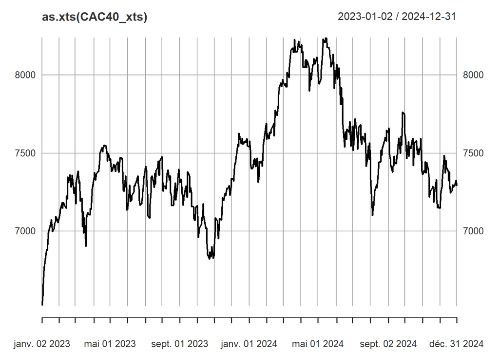

```r
plot(as.xts(CAC40_xts))
```

En observant le graphique, nous constatons que la série semble évoluer de manière non stationnaire, avec des variations significatives à la fois en tendance et en amplitude. Aucune composante additive ou multiplicative claire ne ressort visuellement. Il est également possible que la variance fluctue au fil du temps, renforçant l’hypothèse de non-stationnarité. Une analyse plus approfondie (comme un test de stationnarité ou une décomposition) serait nécessaire pour confirmer ces observations.

Même si ces observations peuvent être faites graphiquement, il sera nécessaire d’appliquer différents tests statistiques pour les vérifier. Ces tests, comme le test de stationnarité (ADF, KPSS, etc.) ou encore des analyses complémentaires sur la décomposition de la série, permettront de confirmer ou d’infirmer les hypothèses initiales concernant la non-stationnarité et l’absence de modèle additif ou multiplicatif.

# Étude de la saisonnalité

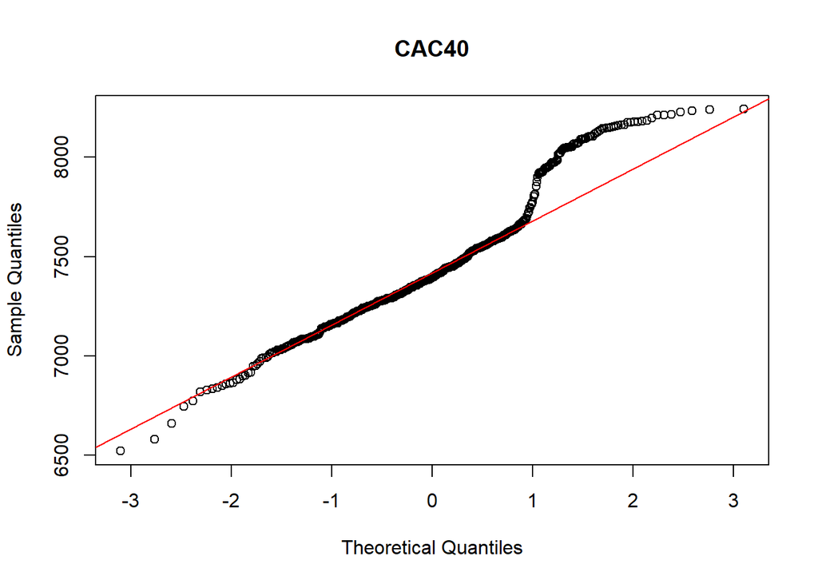

```r
#Graphique de normalité des valeurs du CAC40
qqnorm(CAC40_xts, main = "CAC40")
qqline(CAC40_xts, col = "red")
```

```r
head(CAC40_xts, 5)
```

```
##               [,1]
## 2023-01-02 6521.07
## 2023-01-03 6580.09
## 2023-01-04 6660.60
## 2023-01-05 6744.50
## 2023-01-06 6772.94
```

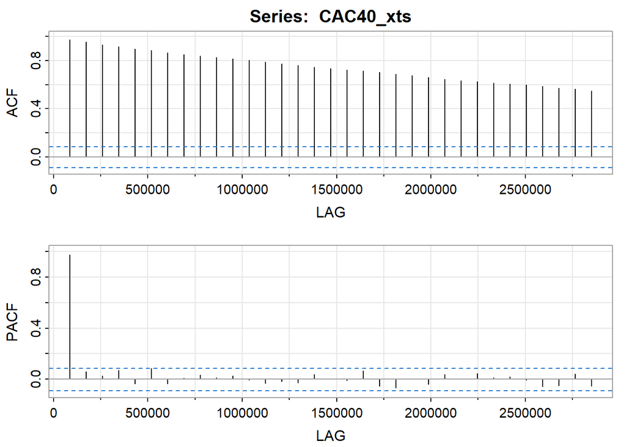

```
##      [,1] [,2] [,3] [,4]  [,5] [,6]  [,7] [,8] [,9] [,10] [,11] [,12] [,13]
## ACF  0.97 0.95 0.93 0.92  0.90 0.88  0.87 0.85 0.84  0.83  0.81  0.80  0.79
## PACF 0.97 0.06 0.03 0.07 -0.04 0.09 -0.04 0.01 0.03  0.01  0.03 -0.01 -0.03
##      [,14] [,15] [,16] [,17] [,18] [,19] [,20] [,21] [,22] [,23] [,24] [,25]
## ACF   0.77  0.76  0.75  0.73  0.72  0.71  0.70  0.69  0.67  0.66  0.65  0.63
## PACF -0.02 -0.03  0.04  0.01 -0.01  0.07 -0.05 -0.07  0.00 -0.04  0.04  0.00
##      [,26] [,27] [,28] [,29] [,30] [,31] [,32] [,33]
## ACF   0.63  0.62  0.61  0.60  0.59  0.57  0.56  0.55
## PACF  0.04  0.01  0.02 -0.01 -0.06 -0.05  0.04 -0.05
```

```r
#Correlogramme
acf2(CAC40_xts)
```

```r
#Saisonnalité
CAC40_ts <- ts(CAC40[,2], start=c(2023, 1) ,frequency = 261)
head(CAC40_ts, 5)
```

```
## Time Series:
## Start = c(2023, 1)
## End = c(2023, 5)
## Frequency = 261
##      Ouverture
## [1,]   6521.07
## [2,]   6580.09
## [3,]   6660.60
## [4,]   6744.50
## [5,]   6772.94
```

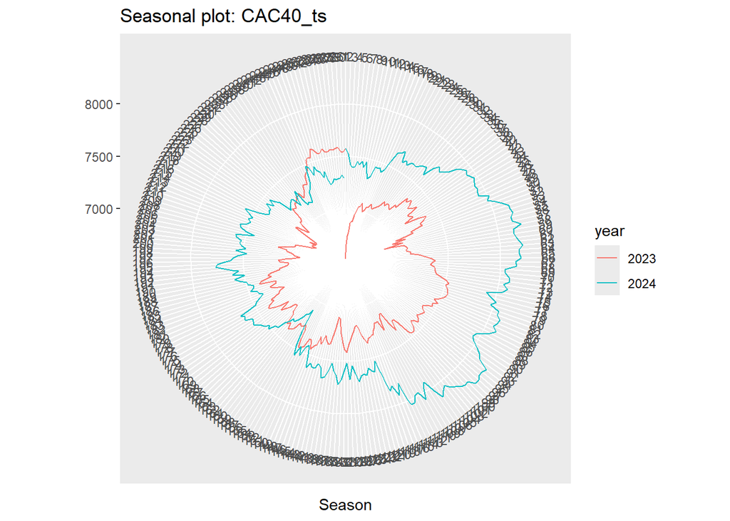

```r
ggseasonplot(CAC40_ts, polar = TRUE)
```

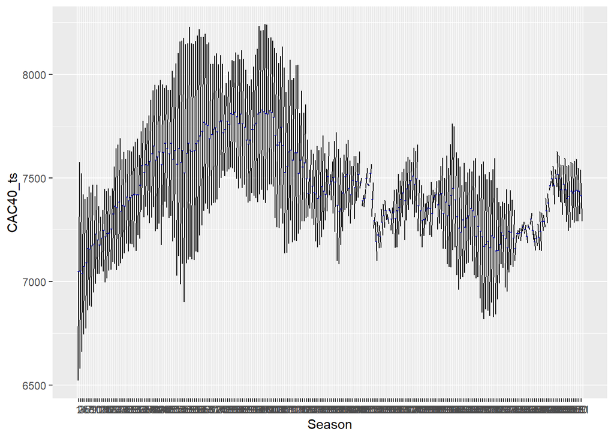

```r
ggsubseriesplot(CAC40_ts)
```

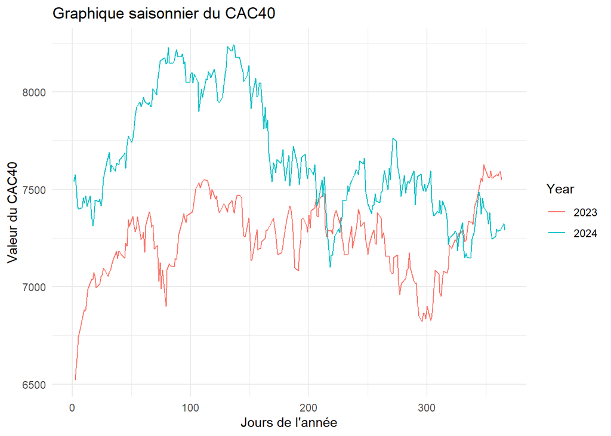

```r
# Ajouter une colonne pour le numéro du jour dans l'année
CAC40 <- CAC40 %>%
  mutate(DayOfYear = as.numeric(format(Date, "%j")),  # Jour dans l'année (1 à 365)
         Year = as.factor(format(Date, "%Y")))  # Année en facteur

# Tracer le graphique sans ts()
ggplot(CAC40, aes(x = DayOfYear, y = Ouverture, color = Year, group = Year)) +
  geom_line() +
  ggtitle("Graphique saisonnier du CAC40") +
  ylab("Valeur du CAC40") +
  xlab("Jours de l'année") +
  theme_minimal()
```

ACF (Autocorrelation Function - Graphique du haut) :

On observe une autocorrélation significative à tous les lags, ce qui indique une forte dépendance des valeurs passées sur les valeurs présentes. Les barres sont bien au-dessus des intervalles de confiance (en pointillés bleus), ce qui montre que la série n’est pas stationnaire. La décroissance progressive (et non un découpage rapide) suggère une tendance dans la série.

PACF (Partial Autocorrelation Function - Graphique du bas) :

En comparant visuellement les variations journalières du CAC 40 sur deux années (2023 et 2024), aucun motif récurrent ou comportement similaire ne se dégage clairement. Contrairement à des séries économiques classiques (comme les ventes mensuelles ou la consommation d’énergie), l’indice boursier est principalement influencé par des facteurs conjoncturels, économiques ou géopolitiques, qui ne suivent pas nécessairement un cycle annuel. Ainsi, bien que des effets calendaires ponctuels puissent exister, aucune saisonnalité marquée ou régulière ne ressort de l’analyse graphique, ce qui justifie le recours à des modèles de prévision sans composante saisonnière explicite.

# Tests de racine unitaire :

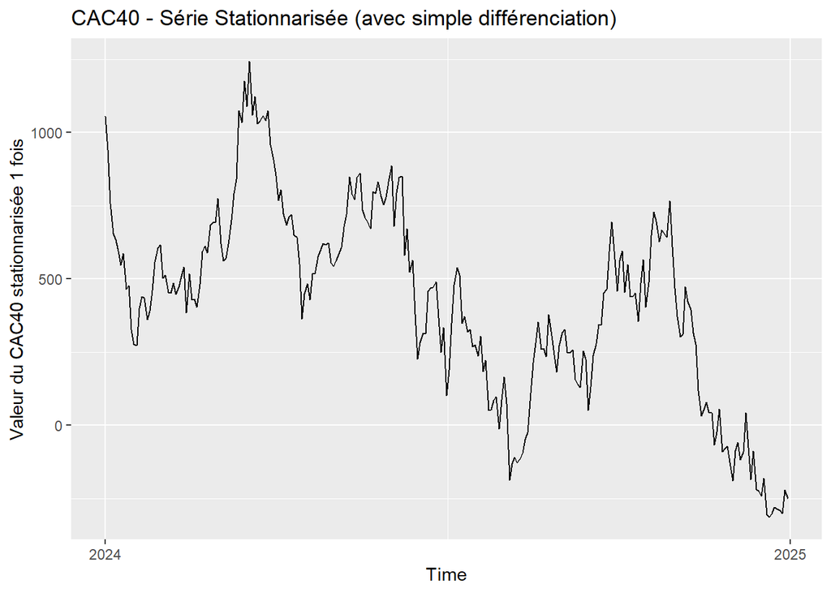

```r
#Tests de racine unitaire pour savoir le nombre de différenciation
cac_statio <- diff(CAC40_ts, lag=261)
cac_statio |> autoplot() + ggtitle("CAC40 - Série Stationnarisée (avec simple différenciation)") + ylab("Valeur du CAC40 stationnarisée 1 fois")
```

```r
#Tests ADF
summary(ur.df(cac_statio, type = "trend", selectlags="AIC")) # stat de test : -2,4899 > -3,42 (seuil critique 5%)
```

```
##
## ###############################################
## # Augmented Dickey-Fuller Test Unit Root Test #
## ###############################################
##
## Test regression trend
##
##
## Call:
## lm(formula = z.diff ~ z.lag.1 + 1 + tt + z.diff.lag)
##
## Residuals:
##      Min       1Q   Median       3Q      Max
## -275.422  -56.688    6.091   59.461  250.721
##
## Coefficients:
##             Estimate Std. Error t value Pr(>|t|)
## (Intercept) 38.18706   19.83232   1.925   0.0553 .
## z.lag.1     -0.05269    0.02116  -2.490   0.0134 *
## tt          -0.15977    0.09262  -1.725   0.0858 .
## z.diff.lag  -0.04231    0.06245  -0.678   0.4987
## ---
## Signif. codes:  0 '***' 0.001 '**' 0.01 '*' 0.05 '.' 0.1 ' ' 1
##
## Residual standard error: 85.82 on 255 degrees of freedom
## Multiple R-squared:  0.02849,    Adjusted R-squared:  0.01706
## F-statistic: 2.492 on 3 and 255 DF,  p-value: 0.06061
##
##
## Value of test-statistic is: -2.4899 2.3627 3.1155
##
## Critical values for test statistics:
##       1pct  5pct 10pct
## tau3 -3.98 -3.42 -3.13
## phi2  6.15  4.71  4.05
## phi3  8.34  6.30  5.36
```

```r
summary(ur.df(cac_statio, type = "drift", selectlags="AIC")) # stat de test : -1,7974 > -2,87
```

```
##
## ###############################################
## # Augmented Dickey-Fuller Test Unit Root Test #
## ###############################################
##
## Test regression drift
##
##
## Call:
## lm(formula = z.diff ~ z.lag.1 + 1 + z.diff.lag)
##
## Residuals:
##     Min      1Q  Median      3Q     Max
## -272.07  -54.88    7.88   58.66  254.30
##
## Coefficients:
##             Estimate Std. Error t value Pr(>|t|)
## (Intercept)  7.44457    8.73318   0.852   0.3948
## z.lag.1     -0.02940    0.01636  -1.797   0.0735 .
## z.diff.lag  -0.05393    0.06233  -0.865   0.3877
## ---
## Signif. codes:  0 '***' 0.001 '**' 0.01 '*' 0.05 '.' 0.1 ' ' 1
##
## Residual standard error: 86.15 on 256 degrees of freedom
## Multiple R-squared:  0.01715,    Adjusted R-squared:  0.009474
## F-statistic: 2.234 on 2 and 256 DF,  p-value: 0.1092
##
##
## Value of test-statistic is: -1.7974 2.0406
##
## Critical values for test statistics:
##       1pct  5pct 10pct
## tau2 -3.44 -2.87 -2.57
## phi1  6.47  4.61  3.79
```

```r
summary(ur.df(cac_statio, type = "none", selectlags="AIC")) # stat de test : -1,8325 > -1,95
```

```
##
## ###############################################
## # Augmented Dickey-Fuller Test Unit Root Test #
## ###############################################
##
## Test regression none
##
##
## Call:
## lm(formula = z.diff ~ z.lag.1 - 1 + z.diff.lag)
##
## Residuals:
##     Min      1Q  Median      3Q     Max
## -266.12  -54.34   12.61   59.52  252.85
##
## Coefficients:
##            Estimate Std. Error t value Pr(>|t|)
## z.lag.1    -0.01840    0.01004  -1.833    0.068 .
## z.diff.lag -0.06130    0.06169  -0.994    0.321
## ---
## Signif. codes:  0 '***' 0.001 '**' 0.01 '*' 0.05 '.' 0.1 ' ' 1
##
## Residual standard error: 86.11 on 257 degrees of freedom
## Multiple R-squared:  0.01716,    Adjusted R-squared:  0.009507
## F-statistic: 2.243 on 2 and 257 DF,  p-value: 0.1082
##
##
## Value of test-statistic is: -1.8325
##
## Critical values for test statistics:
##       1pct  5pct 10pct
## tau1 -2.58 -1.95 -1.62
```

```r
# Tous les résultats indiquent non stationnarité

#Tests de Phillips Perron
summary(ur.pp(cac_statio,model = "trend", type = "Z-tau", lags = "short")) # stat de test : -2.7878 > -3.43
```

```
##
## ##################################
## # Phillips-Perron Unit Root Test #
## ##################################
##
## Test regression with intercept and trend
##
##
## Call:
## lm(formula = y ~ y.l1 + trend)
##
## Residuals:
##      Min       1Q   Median       3Q      Max
## -272.733  -55.961    5.035   57.475  250.271
##
## Coefficients:
##             Estimate Std. Error t value Pr(>|t|)
## (Intercept) 18.92209   10.27554   1.841   0.0667 .
## y.l1         0.94336    0.02080  45.363   <2e-16 ***
## trend       -0.16237    0.09195  -1.766   0.0786 .
## ---
## Signif. codes:  0 '***' 0.001 '**' 0.01 '*' 0.05 '.' 0.1 ' ' 1
##
## Residual standard error: 85.77 on 257 degrees of freedom
## Multiple R-squared:  0.9341, Adjusted R-squared:  0.9336
## F-statistic:  1820 on 2 and 257 DF,  p-value: < 2.2e-16
##
##
## Value of test-statistic, type: Z-tau  is: -2.7878
##
##            aux. Z statistics
## Z-tau-mu              1.6885
## Z-tau-beta           -1.8050
##
## Critical values for Z statistics:
##                      1pct      5pct     10pct
## critical values -3.996629 -3.428398 -3.137312
```

```r
summary(ur.pp(cac_statio, model = "constant", type = "Z-tau", lags = "short")) # stat de test : -2.068 > -2.86
```

```
##
## ##################################
## # Phillips-Perron Unit Root Test #
## ##################################
##
## Test regression with intercept
##
##
## Call:
## lm(formula = y ~ y.l1)
##
## Residuals:
##      Min       1Q   Median       3Q      Max
## -268.434  -53.355    7.628   58.679  253.367
##
## Coefficients:
##             Estimate Std. Error t value Pr(>|t|)
## (Intercept)  8.98254    8.63206   1.041    0.299
## y.l1         0.96676    0.01609  60.068   <2e-16 ***
## ---
## Signif. codes:  0 '***' 0.001 '**' 0.01 '*' 0.05 '.' 0.1 ' ' 1
##
## Residual standard error: 86.12 on 258 degrees of freedom
## Multiple R-squared:  0.9333, Adjusted R-squared:  0.933
## F-statistic:  3608 on 1 and 258 DF,  p-value: < 2.2e-16
##
##
## Value of test-statistic, type: Z-tau  is: -2.068
##
##          aux. Z statistics
## Z-tau-mu            1.0431
##
## Critical values for Z statistics:
##                      1pct      5pct     10pct
## critical values -3.457006 -2.872754 -2.572697
```

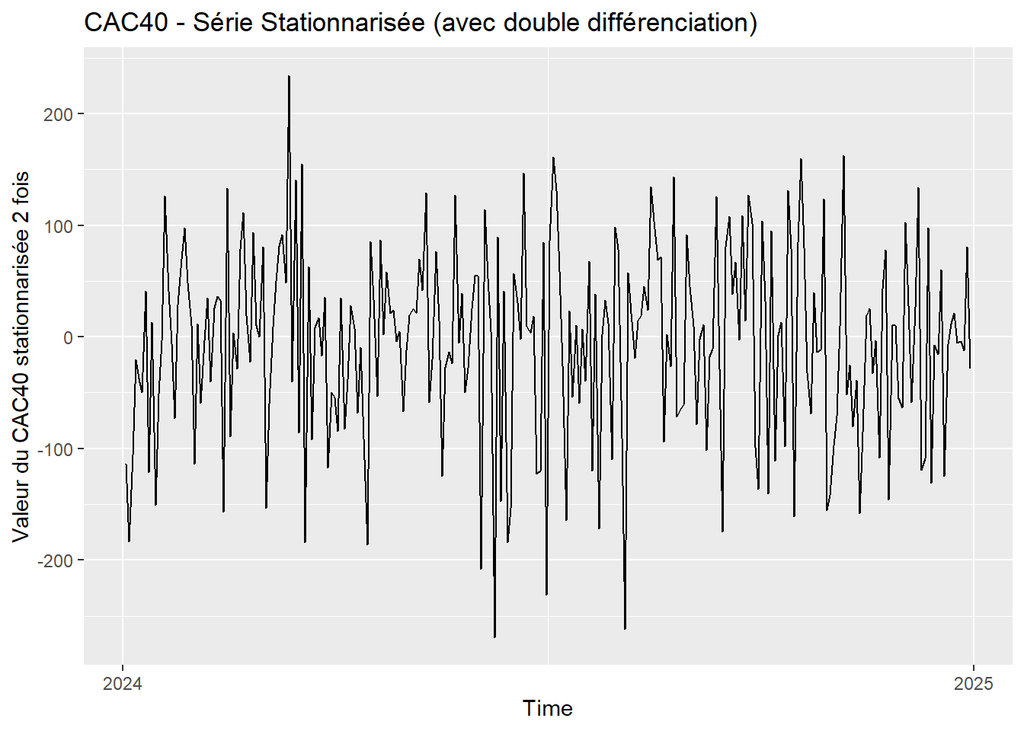

```r
#On remarque avec les différents tests qu'il faut différencier la série une deuxième fois.

cac_statio2 <- diff(diff(CAC40_ts), lag = 261)
cac_statio2 |> autoplot() + ggtitle("CAC40 - Série Stationnarisée (avec double différenciation)") + ylab("Valeur du CAC40 stationnarisée 2 fois")
```

```r
summary(ur.df(cac_statio2, type = "trend", selectlags="AIC")) # stat de test : -11.75 < -3.42
```

```
##
## ###############################################
## # Augmented Dickey-Fuller Test Unit Root Test #
## ###############################################
##
## Test regression trend
##
##
## Call:
## lm(formula = z.diff ~ z.lag.1 + 1 + tt + z.diff.lag)
##
## Residuals:
##     Min      1Q  Median      3Q     Max
## -265.69  -54.83    7.46   55.62  238.98
##
## Coefficients:
##             Estimate Std. Error t value Pr(>|t|)
## (Intercept) -0.33634   10.83261  -0.031    0.975
## z.lag.1     -1.06695    0.09079 -11.752   <2e-16 ***
## tt          -0.02965    0.07206  -0.412    0.681
## z.diff.lag  -0.01171    0.06208  -0.189    0.851
## ---
## Signif. codes:  0 '***' 0.001 '**' 0.01 '*' 0.05 '.' 0.1 ' ' 1
##
## Residual standard error: 86.2 on 254 degrees of freedom
## Multiple R-squared:  0.5441, Adjusted R-squared:  0.5387
## F-statistic:   101 on 3 and 254 DF,  p-value: < 2.2e-16
##
##
## Value of test-statistic is: -11.7521 46.0738 69.093
##
## Critical values for test statistics:
##       1pct  5pct 10pct
## tau3 -3.98 -3.42 -3.13
## phi2  6.15  4.71  4.05
## phi3  8.34  6.30  5.36
```

```r
summary(ur.df(cac_statio2, type = "drift", selectlags="AIC")) # stat de test : -11.77 < -2.87
```

```
##
## ###############################################
## # Augmented Dickey-Fuller Test Unit Root Test #
## ###############################################
##
## Test regression drift
##
##
## Call:
## lm(formula = z.diff ~ z.lag.1 + 1 + z.diff.lag)
##
## Residuals:
##      Min       1Q   Median       3Q      Max
## -265.769  -53.500    7.897   56.909  241.337
##
## Coefficients:
##             Estimate Std. Error t value Pr(>|t|)
## (Intercept) -4.20414    5.37648  -0.782    0.435
## z.lag.1     -1.06650    0.09063 -11.767   <2e-16 ***
## z.diff.lag  -0.01191    0.06198  -0.192    0.848
## ---
## Signif. codes:  0 '***' 0.001 '**' 0.01 '*' 0.05 '.' 0.1 ' ' 1
##
## Residual standard error: 86.06 on 255 degrees of freedom
## Multiple R-squared:  0.5438, Adjusted R-squared:  0.5402
## F-statistic:   152 on 2 and 255 DF,  p-value: < 2.2e-16
##
##
## Value of test-statistic is: -11.7672 69.2516
##
## Critical values for test statistics:
##       1pct  5pct 10pct
## tau2 -3.44 -2.87 -2.57
## phi1  6.47  4.61  3.79
```

```r
summary(ur.df(cac_statio2, type = "none", selectlags="AIC")) # stat de test : -11.75 < -1.95
```

```
##
## ###############################################
## # Augmented Dickey-Fuller Test Unit Root Test #
## ###############################################
##
## Test regression none
##
##
## Call:
## lm(formula = z.diff ~ z.lag.1 - 1 + z.diff.lag)
##
## Residuals:
##      Min       1Q   Median       3Q      Max
## -269.969  -57.966    3.764   52.658  236.715
##
## Coefficients:
##            Estimate Std. Error t value Pr(>|t|)
## z.lag.1    -1.06066    0.09026 -11.752   <2e-16 ***
## z.diff.lag -0.01502    0.06180  -0.243    0.808
## ---
## Signif. codes:  0 '***' 0.001 '**' 0.01 '*' 0.05 '.' 0.1 ' ' 1
##
## Residual standard error: 86 on 256 degrees of freedom
## Multiple R-squared:  0.5427, Adjusted R-squared:  0.5391
## F-statistic: 151.9 on 2 and 256 DF,  p-value: < 2.2e-16
##
##
## Value of test-statistic is: -11.7517
##
## Critical values for test statistics:
##       1pct  5pct 10pct
## tau1 -2.58 -1.95 -1.62
```

Afin d’évaluer la stationnarité de la série du CAC40 et de déterminer le nombre de différenciations nécessaires avant modélisation, plusieurs tests de racine unitaire ont été appliqués.

Dans un premier temps, une première différenciation saisonnière (lag = 261, correspondant au nombre approximatif de jours de bourse par an) est effectuée. La série obtenue est ensuite soumise à plusieurs tests classiques :

Le test de Dickey-Fuller augmenté (ADF) avec différentes spécifications (avec tendance, avec dérive, sans constante).

Le test de Phillips-Perron, également sous les hypothèses de tendance et de constante.

Les résultats indiquent que, malgré cette première transformation, la série reste non stationnaire. Une seconde différenciation (non saisonnière cette fois) est donc appliquée, permettant d’obtenir une série stationnaire, comme le suggèrent les diagnostics visuels et les tests.

Cette étape est essentielle pour garantir la validité des modèles de prévision tels qu’ARIMA ou Holt-Winters, qui nécessitent une série stationnaire en entrée.

# Prévisions

## Import des vraies données du mois de janvier 2025

```r
CAC40_janvier <- read_excel("data/dates_pred.xlsx")

CAC40_janvier$Date <- as.POSIXct(CAC40_janvier$Date)
```

## ARIMA

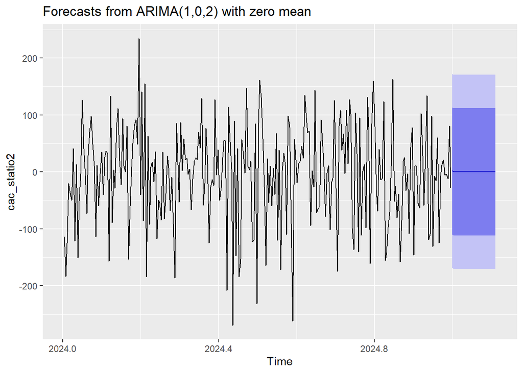

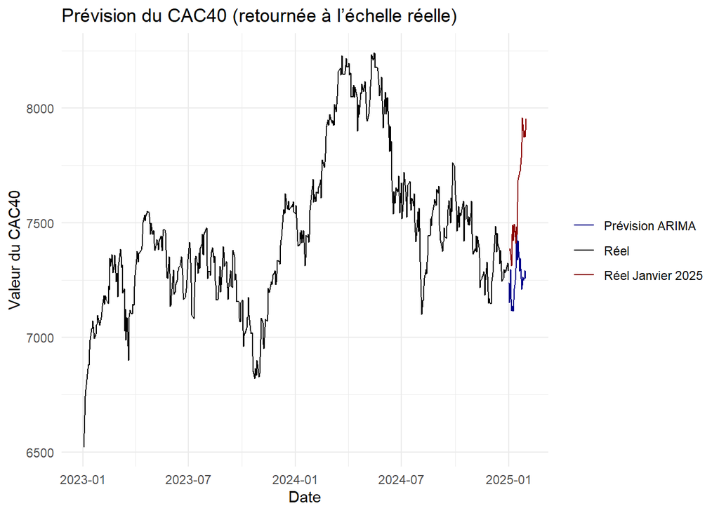

La prévision obtenue via le modèle ARIMA s’avère relativement cohérente avec la tendance observée. Le modèle propose une évolution modérée, sans rupture brutale, ce qui traduit une bonne prise en compte de la dynamique globale de la série. Toutefois, il n’anticipe pas la forte croissance observée en janvier 2025. Ce décalage peut s’expliquer par le caractère linéaire et conservateur du modèle, peu réactif aux changements soudains de tendance.

## Holt-Winters

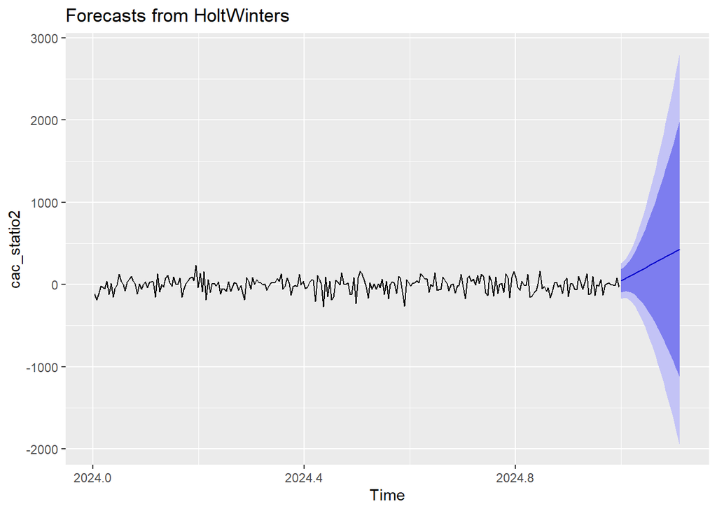

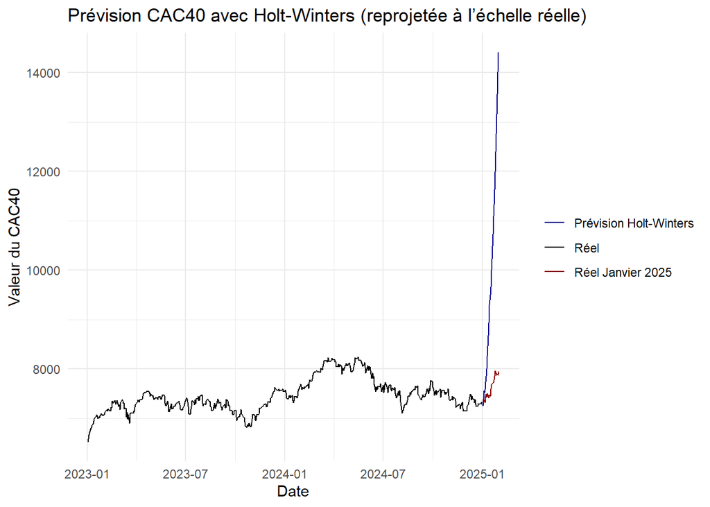

La méthode de Holt-Winters, appliquée ici sans composante saisonnière (gamma = FALSE), propose une trajectoire fortement haussière, quasi exponentielle. Si cette courbe suit la direction générale de la tendance observée, elle surestime clairement l’ampleur de la hausse. Cela montre que le modèle accorde une importance excessive à la pente récente, sans réellement ajuster la dynamique à la réalité du marché, ce qui peut poser problème dans un contexte boursier où les mouvements ne sont pas toujours réguliers.

## Prophet

```
## # A tibble: 6 × 2
##   ds                      y
##   <dttm>              <dbl>
## 1 2023-01-02 00:00:00 6521.
## 2 2023-01-03 00:00:00 6580.
## 3 2023-01-04 00:00:00 6661.
## 4 2023-01-05 00:00:00 6744.
## 5 2023-01-06 00:00:00 6773.
## 6 2023-01-09 00:00:00 6862.
```

```
## Disabling yearly seasonality. Run prophet with yearly.seasonality=TRUE to override this.
```

```
## Disabling daily seasonality. Run prophet with daily.seasonality=TRUE to override this.
```

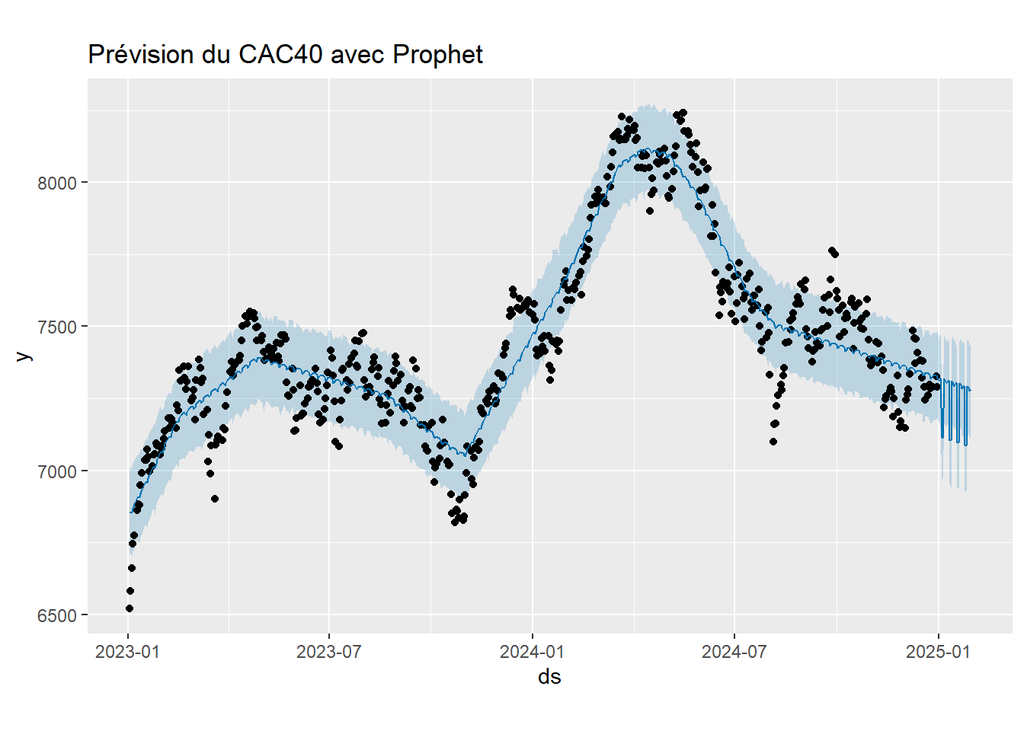

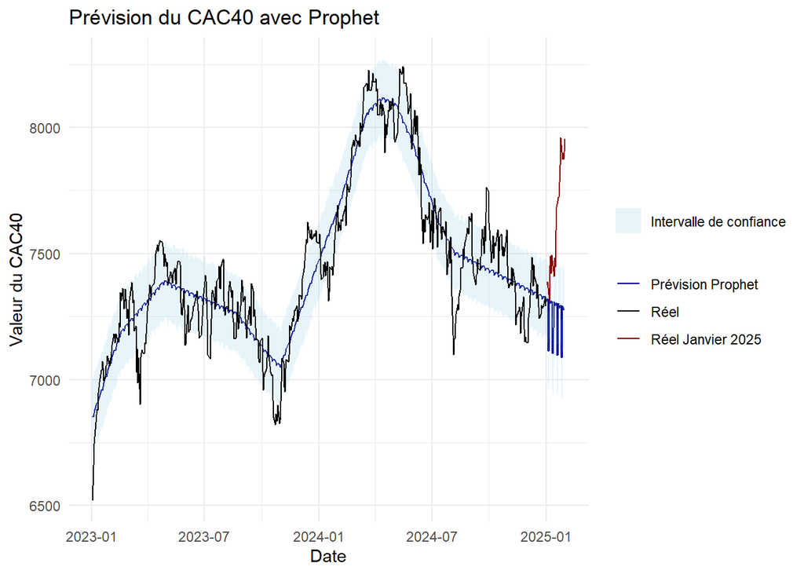

# Synthèse

# Extraction des données pertinentes pour le Power BI

```r
#Série de base
#write.csv(CAC40, "output/CAC40.csv", row.names = FALSE)

#Prévision ARIMA
#write.csv(final_forecast_ARIMA, "output/final_forecast_ARIMA.csv", row.names = FALSE)

#Prévision Holt_Winters
#write.csv(final_forecast_HW, "output/final_forecast_HW.csv", row.names = FALSE)


#Prévision Prophet
#write.csv(forecast, "output/final_forecast_prophet.csv", row.names = FALSE)
```

# Conclusion

À travers cette étude, nous avons évalué trois approches classiques de prévision des séries temporelles appliquées à l’indice boursier CAC 40 : ARIMA, Holt-Winters, et Prophet. Chacune de ces méthodes présente des caractéristiques spécifiques et des performances variables face à la nature volatile et peu saisonnière des données financières.

Le modèle ARIMA s’est avéré le plus robuste, reproduisant de manière relativement fidèle la dynamique globale de la série, bien qu’avec une certaine prudence. Sa capacité à modéliser la tendance sans excès de volatilité en fait un outil pertinent dans un contexte où les mouvements brusques restent difficiles à anticiper.

La méthode Holt-Winters, bien qu’elle capte efficacement la tendance haussière récente, tend à surestimer l’amplitude des variations, traduisant une sensibilité accrue aux dynamiques récentes. Ce comportement peut conduire à des prévisions trop optimistes, en particulier sur des séries financières sujettes à des retournements rapides.

Enfin, le modèle Prophet, pourtant réputé pour sa gestion automatique des tendances et des saisonnalités, s’est montré inadapté ici. L’absence de motifs saisonniers marqués dans la série limite son efficacité, et le modèle n’a pas su capter la hausse constatée en janvier 2025.

Cette comparaison met en lumière l’importance cruciale du choix du modèle en fonction de la nature de la série analysée. Dans un environnement boursier, où les comportements sont souvent guidés par des facteurs exogènes, géopolitiques ou économiques, les modèles simples mais flexibles comme ARIMA peuvent s’avérer plus performants que des outils plus complexes basés sur des hypothèses de régularité.